# KEY 07 ANOVA

## GRADED TUKEY plot

3.17 Make a plot of the Tukey HSD results.

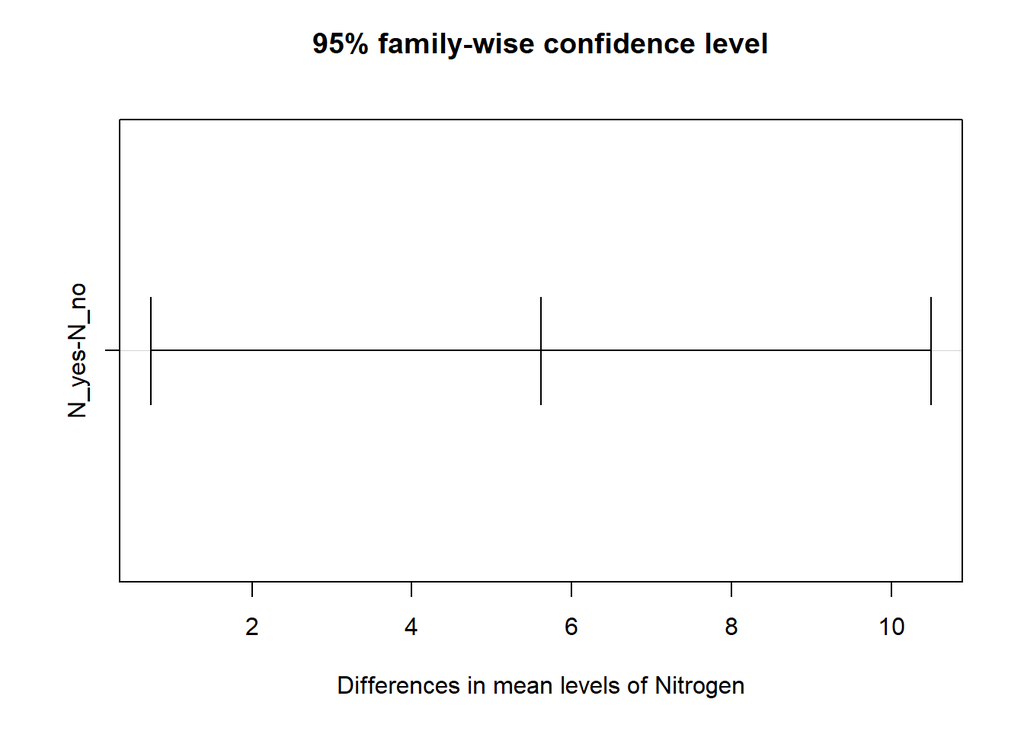

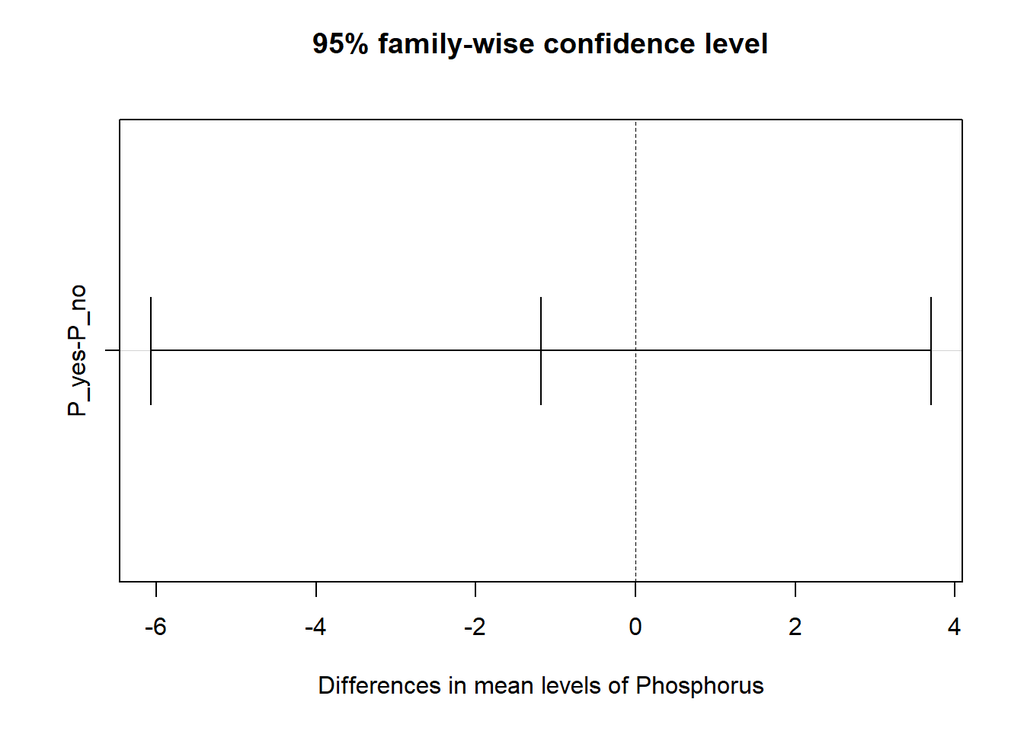

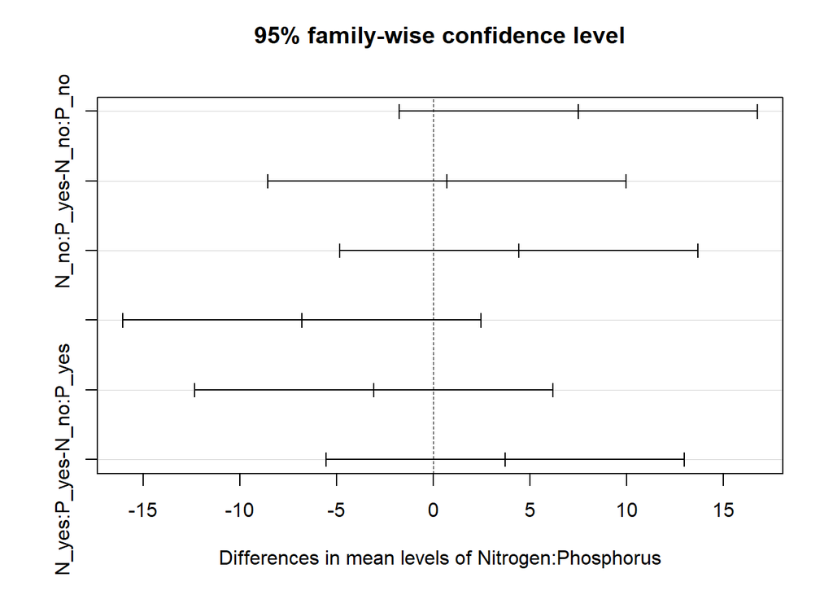

```r
plot(TukeyHSD(wheat_aov))
```

3.18 Finally, interpret the results of the Tukey HSD here. You can be broad and summarize these results generally.

```r
# 1.18
# the results of the TukeyHSD indicate that the only difference in this experiment was when Nitrogen was added (adjusted p-value = 0.026). All the other pairwise comparisons were not significant (adjusted p-value > 0.05)
```

3.19 Based on the interaction plot above, you may have guessed that there would be a significant interaction effect. However, the last few questions should have made it clear that there was not a statistically significant interaction effect (if you got a different result, double check your code and/or ask me). Here, add a comment discussing why you think the interaction plot disagrees with the statistical analyses.

```r
# it appeared that there was a difference in slope in the interaction plot
# however, this difference in slope must not have been large enough to be statistically meaningful.
# similar to how we may estimate a difference in means between groups but the variation is too high for this to be statistically meaningful.
```